# Models for Football Data

# Data Processing

We load football data from a Kaggle containing Spanish League results(https://www.kaggle.com/datasets/ricardomoya/football-matches-of-spanish-league), for the 2016-17 and 2017-18 seasons.

```r
library("dplyr")
library("tidyr")
library("ggplot2")
library("reshape2")
library("nloptr")
library("data.table")

data <- read.csv("https://raw.githubusercontent.com/plamenapp/MastersThesis/master/FMEL_Dataset.csv")


data <- data %>%
  filter(season == "2016-17" | season == "2017-18" )

head(data)
```

|  | id | season | division | round | localTeam | visitorTeam | localGoals | visitorGoals | date | timestamp |
| --- | --- | --- | --- | --- | --- | --- | --- | --- | --- | --- |
| 1 | 35464 | 2016-17 | 1 | 1 | Malaga | Osasuna | 1 | 1 | 19/08/2016 | 1471557600 |
| 2 | 35465 | 2016-17 | 1 | 1 | Deportivo | Eibar | 2 | 1 | 19/08/2016 | 1471557600 |
| 3 | 35466 | 2016-17 | 1 | 1 | Barcelona | Betis | 6 | 2 | 20/08/2016 | 1471644000 |
| 4 | 35467 | 2016-17 | 1 | 1 | Granada | Villarreal | 1 | 1 | 20/08/2016 | 1471644000 |
| 5 | 35468 | 2016-17 | 1 | 1 | Sevilla | Espanol | 6 | 4 | 20/08/2016 | 1471644000 |
| 6 | 35469 | 2016-17 | 1 | 1 | Sporting de Gijon | Atletico de Bilbao | 2 | 1 | 21/08/2016 | 1471730400 |

Reshaping the data so that we have one team per row.

```r
melt_results <- function(results_df) {
  results_df %>%
    # select only relevant columns
    select(localTeam, visitorTeam, localGoals, visitorGoals, date) %>%
    gather(location, team,  -localGoals, -visitorGoals, -date) %>%
    # calculate goals for/against the team
    mutate(g_for = case_when(
      location == "localTeam" ~ localGoals,
      location == "visitorTeam" ~ visitorGoals
    )) %>%
    mutate(g_ag = case_when(
      location == "localTeam" ~ visitorGoals,
      location == "visitorTeam" ~ localGoals
    ))
}

data_melted <- data %>%
  melt_results()

head(data_melted)
```

|  | localGoals | visitorGoals | date | location | team | g_for | g_ag |
| --- | --- | --- | --- | --- | --- | --- | --- |
| 1 | 1 | 1 | 19/08/2016 | localTeam | Malaga | 1 | 1 |
| 2 | 2 | 1 | 19/08/2016 | localTeam | Deportivo | 2 | 1 |
| 3 | 6 | 2 | 20/08/2016 | localTeam | Barcelona | 6 | 2 |
| 4 | 1 | 1 | 20/08/2016 | localTeam | Granada | 1 | 1 |
| 5 | 6 | 4 | 20/08/2016 | localTeam | Sevilla | 6 | 4 |
| 6 | 2 | 1 | 21/08/2016 | localTeam | Sporting de Gijon | 2 | 1 |

Creating a ranking table for each team’s statistics and ranking estimates. W,L and D are each team’s number of wins, loses and draws respectively. GF,GA and GD represent the sum of goals for, against and the goal differences for each team. Points are calculated by the formula “Pts = 3W + 1D” and teams are ranked accordingly.

```r
game_statistics <- data_melted %>%
  mutate(win = ifelse(g_for > g_ag, 1,0),
         loss = ifelse(g_for < g_ag, 1,0),
         draw = ifelse(g_for == g_ag, 1,0))

game_statistics <- game_statistics %>%
  group_by(team) %>%
  summarise ( W = sum(win),
           L = sum (loss),
           D = sum(draw),
           GF = sum(g_for),
           GA = sum(g_ag),
           GD = GF - GA,
           Pts = 3*W + 1*D
           ) %>%
  arrange(desc(Pts))

head(game_statistics)
```

| team | W | L | D | GF | GA | GD | Pts |
| --- | --- | --- | --- | --- | --- | --- | --- |
| Barcelona | 56 | 5 | 15 | 215 | 66 | 149 | 183 |
| Real Madrid | 51 | 9 | 16 | 200 | 85 | 115 | 169 |
| Atletico de Madrid | 46 | 11 | 19 | 128 | 49 | 79 | 157 |
| Huesca | 37 | 20 | 27 | 114 | 83 | 31 | 138 |
| Levante | 36 | 22 | 22 | 101 | 90 | 11 | 130 |
| Sevilla | 38 | 22 | 16 | 118 | 107 | 11 | 130 |

# Poisson Model - 1 (Maher)

We group all teams together into “home” and “away” categories and plot the distribution of the goals.

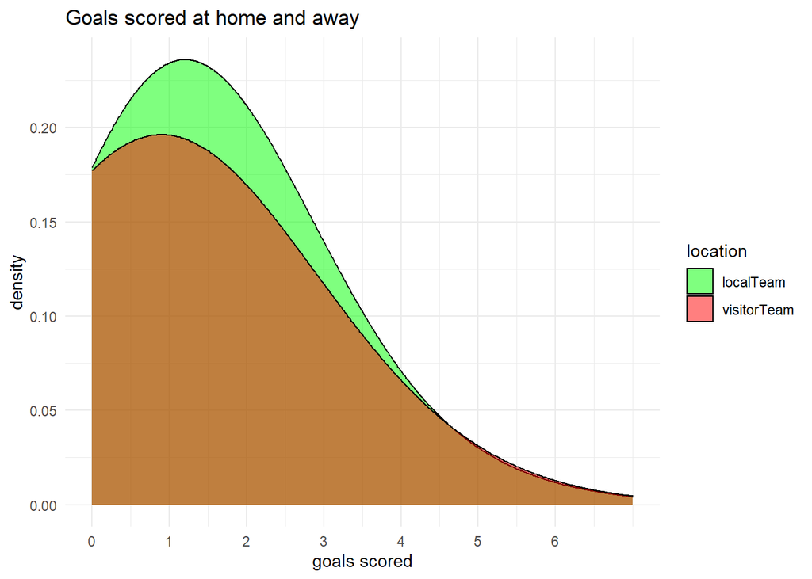

```r
data_melted %>%
  ggplot(., aes(x = g_for, fill = location)) +
  geom_density(adjust = 8, alpha = 0.5) +
  scale_fill_manual(values = c("green", "red")) +
  scale_x_continuous(breaks = 0:6) +
  labs(title = "Goals scored at home and away",
       x = "goals scored",
       y = "density") +
  theme_minimal()
```

It is evident that the home team tends to score more than the visiting one. Also both charts look like a Poisson distribution.For the home team we take the average number of goals scored per match as the mean of a Poisson distribution and we can see how well the previous graph fits a simulated Poisson process.

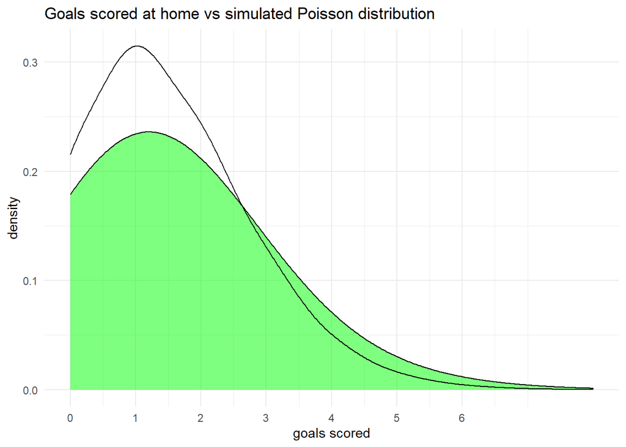

```r
p1 <- data_melted %>%
  filter( location == "localTeam") %>%
  ggplot(., aes(x = g_for)) +
  geom_density(adjust = 8, alpha = 0.5, aes(fill= "green")) +
  scale_fill_manual(values = c("green")) +
  scale_x_continuous(breaks = 0:6) +
  labs(title = "Goals scored at home vs simulated Poisson distribution",
       x = "goals scored",
       y = "density") +
  theme_minimal() +
  theme(legend.position = "none")

local_team_data <- data_melted %>%
  filter( location == "localTeam")

simulated_poisson <- data.frame(dist = rpois(100000, mean(local_team_data$localGoals)))

p1 + geom_density(data = simulated_poisson, aes(x = dist),
                  fill = NA, adjust = 8, alpha = 0.2)
```

In a similar fashion one can conclude that the goals scored by the visiting team also follow a Poisson process but with a different mean.

Hence, the probability of team i scoring x goals against team j is:
$$P(x_i=x) = \frac{\alpha^x_ie^{−\alpha_i}}{x!}$$
Let n be the number of teams and $x_k$ and $y_k \in 0,1,2,3,..$ are the final scores of the home and away team, respectively in the $k$-th match.

Where $\alpha$ can be approximated using the maximum likelihood estimator for Poisson distribution, namely

$$\hat{\alpha}_i= \frac{1}{m_i}\sum_{k=1}^{m_i} x_k$$
and $m_i$ is the number of matches that team $i$ participated in. Essentially $\alpha$ is an estimate of each team’s attack rating. Similarly, we can estimate each team’s defence parameter $\beta_j$ as the average number of goals scored by their opponents which also follows a Poisson process.

Lastly we introduce $\gamma$ as a measure of the “home advantage”. As we saw earlier, in general football teams tend to perform better at home, so we want to factor that in.

$\gamma$ can be calculated as the sum of home goals divided by the sum of away goals.

$$\gamma = \frac{\sum x}{\sum y}$$
Ultimately we arrive at the following Poisson model which takes into account the team’s attack, the defence of its opponent and if the team is playing at home.

$$X_i,_j \sim Poisson(\alpha_i\beta_j\gamma)$$
$$Y_i,_j\sim Poisson(\alpha_j\beta_i)$$
Estimating gamma - home advantage

```r
gama = sum(data$localGoals)/sum(data$visitorGoals)
gama
```

```
## [1] 1.391109
```

Estimating alfa and beta - average number of goals for and against each team

```r
data_model1 <- data_melted %>%
  group_by(team) %>%
  summarise(alfa = mean(g_for),
            beta = mean(g_ag))

head(data_model1)
```

| team | alfa | beta |
| --- | --- | --- |
| Alaves | 1.0657895 | 1.2236842 |
| Albacete | 0.8333333 | 1.0952381 |
| Alcorcon | 0.8214286 | 1.0119048 |
| Almeria | 0.9761905 | 1.1190476 |
| Atletico de Bilbao | 1.2368421 | 1.2105263 |
| Atletico de Madrid | 1.6842105 | 0.6447368 |

The following code estimates the outcome for each game in our dataset based on the calculated parameters. The local team estimate is multiplied by gamma to account for the “home advantage”.

```r
model1_output <- left_join(data, data_model1[c("team", "alfa", "beta")], by = c("localTeam" = "team"))
model1_output <- model1_output %>%
  rename(alfa_local=alfa) %>%
  rename(beta_local=beta)

model1_output <- left_join(model1_output, data_model1[c("team", "alfa", "beta")], by = c("visitorTeam" = "team"))
model1_output <- model1_output %>%
  rename(alfa_visitor=alfa) %>%
  rename(beta_visitor=beta)

model1_output <- model1_output %>%
  mutate(prediction_local = alfa_local*beta_visitor*gama,
         prediction_visit = alfa_visitor*beta_local)

head(model1_output)
```

|  | id | season | division | round | localTeam | visitorTeam | localGoals | visitorGoals | date | timestamp | alfa_local | beta_local | alfa_visitor | beta_visitor | prediction_local | prediction_visit |
| --- | --- | --- | --- | --- | --- | --- | --- | --- | --- | --- | --- | --- | --- | --- | --- | --- |
| 1 | 35464 | 2016-17 | 1 | 1 | Malaga | Osasuna | 1 | 1 | 19/08/2016 | 1471557600 | 0.9605263 | 1.5263158 | 1.050000 | 1.600000 | 2.137914 | 1.602632 |
| 2 | 35465 | 2016-17 | 1 | 1 | Deportivo | Eibar | 2 | 1 | 19/08/2016 | 1471557600 | 1.0657895 | 1.8026316 | 1.315789 | 1.328947 | 1.970336 | 2.371884 |
| 3 | 35466 | 2016-17 | 1 | 1 | Barcelona | Betis | 6 | 2 | 20/08/2016 | 1471644000 | 2.8289474 | 0.8684211 | 1.328947 | 1.644737 | 6.472653 | 1.154086 |
| 4 | 35467 | 2016-17 | 1 | 1 | Granada | Villarreal | 1 | 1 | 20/08/2016 | 1471644000 | 1.0625000 | 1.6500000 | 1.486842 | 1.092105 | 1.614189 | 2.453289 |
| 5 | 35468 | 2016-17 | 1 | 1 | Sevilla | Espanol | 6 | 4 | 20/08/2016 | 1471644000 | 1.5526316 | 1.4078947 | 1.118421 | 1.210526 | 2.614591 | 1.574619 |
| 6 | 35469 | 2016-17 | 1 | 1 | Sporting de Gijon | Atletico de Bilbao | 2 | 1 | 21/08/2016 | 1471730400 | 1.2750000 | 1.4000000 | 1.236842 | 1.210526 | 2.147066 | 1.731579 |

We check that the estimated parameters indeed predict the observed results for each team.The top three teams predicted by the model are indeed in top 3 of the real ranking but in different order. Overall the ranking of the top six teams according to the model does not match real life results.

```r
game_predicted_statistics <- model1_output %>%
  # select only relevant columns
  select(localTeam, visitorTeam, prediction_local, prediction_visit, date) %>%
  gather(location, team,  -prediction_local,-prediction_visit, -date) %>%
  # calculate goals for/against the team
  mutate(g_for = case_when(
    location == "localTeam" ~ prediction_local,
    location == "visitorTeam" ~ prediction_visit
  )) %>%
  mutate(g_ag = case_when(
    location == "localTeam" ~ prediction_visit,
    location == "visitorTeam" ~ prediction_local
  )) %>%
  mutate(win = ifelse(g_for > g_ag, 1,0),
         loss = ifelse(g_for < g_ag, 1,0),
         draw = ifelse(g_for == g_ag, 1,0)) %>%
  group_by(team) %>%
  summarise ( W = sum(win),
              L = sum (loss),
              D = sum(draw),
              GF = sum(g_for),
              GA = sum(g_ag),
              GD = GF - GA,
              Pts = 3*W + 1*D
  ) %>%
  arrange(desc(Pts))

head(game_predicted_statistics)
```

| team | W | L | D | GF | GA | GD | Pts |
| --- | --- | --- | --- | --- | --- | --- | --- |
| Atletico de Madrid | 72 | 4 | 0 | 211.9489 | 82.89944 | 129.04949 | 216 |
| Barcelona | 72 | 4 | 0 | 352.9818 | 106.90640 | 246.07542 | 216 |
| Real Madrid | 72 | 4 | 0 | 325.2090 | 138.73812 | 186.47087 | 216 |
| Cadiz | 67 | 17 | 0 | 140.0993 | 92.62252 | 47.47682 | 201 |
| Huesca | 67 | 17 | 0 | 163.5711 | 110.45919 | 53.11196 | 201 |
| Tenerife | 64 | 20 | 0 | 154.6693 | 116.13631 | 38.53304 | 192 |

# Alternative approach to solving for the parameters of Model 1

Once again we are interested in the following model which assumes independence of $X_i,_j$ and $Y_i,_j$:

$$P(X_i,_j = x, Y_i,_j = y) = \frac{\lambda e^{-\lambda}}{x!}\frac{\mu e^{-\mu}}{x!}$$
where

$$\lambda = \alpha_i\beta_j\gamma$$
$$\mu = \alpha_j\beta_i$$
The likelihood function of the Poisson model is given by

$$L(\alpha_i,\beta_i,\gamma,i = 1,2,...,n) = \prod_{k=1}^{N} e^{-\lambda_k}\lambda_k^{x_k} e^{-\mu_k}\mu_k^{x_k}$$
We’d like to find the set of parameters that will minimize the likelihood function.

We start by creating a new data set containing only the relevant information.

```r
x = data[,c(5:8)]
n = n_distinct(x$localTeam)
teams <- matrix(c(unique(x$localTeam),1:n), nrow = n)
teams <- as.data.frame(teams)
x <- left_join(x,teams, by = c("localTeam" = "V1"))
x <- left_join(x,teams, by = c("visitorTeam" = "V1"))

x <- x %>%
  rename(local_team_index = V2.x,
         visitor_team_index = V2.y)
x <-x [,c(3:6)]

x <- as.data.table(x)

x$local_team_index <- as.integer(x$local_team_index)
x$visitor_team_index <- as.integer(x$visitor_team_index)

x <- as.data.table(x)
head(x)
```

| localGoals | visitorGoals | local_team_index | visitor_team_index |
| --- | --- | --- | --- |
| 1 | 1 | 1 | 13 |
| 2 | 1 | 2 | 14 |
| 6 | 2 | 3 | 11 |
| 1 | 1 | 4 | 20 |
| 6 | 4 | 5 | 12 |
| 2 | 1 | 6 | 19 |

In what follows we apply a constraint optimization algorithm where we are using the following constraint:

$$\sum_{i=1}^n\frac{\alpha_i}{n}=1$$
or the equivalent

$$ln(\sum_{i=1}^n\frac{\alpha_i}{n}=1) = 0$$

```r
f_lambda = function(alfa, beta, gama){
  gama*alfa[x$local_team_index]*beta[x$visitor_team_index]
}

f_mu = function(alfa, beta, gama){
  alfa[x$local_team_index]*beta[x$visitor_team_index]
}

f_l = function(w) {
  alfa = w[1:n]
  beta = w[(n+1):(2*n)]
  gama = w[2*n+1]
  lambda = f_lambda(alfa, beta, gama)
  mu =     f_mu(alfa, beta, gama)

  - sum(x$localGoals * log(lambda) + x$visitorGoals * log(mu) - lambda - mu)
}

eq = function(w) {
  alfa = w[1:n]
  c(log(sum(alfa)/n))
}

w0 = rep(1, 2*n+1)
options(warn = -1)

suppressMessages(
S <- slsqp(w0, fn = f_l,
           heq = eq,
           control = list(xtol_rel = 1e-9, print_level = 0)
            )
)
S
```

```
## $par
##  [1] 1.0104147 1.0945945 1.5312412 1.0279533 1.1282117 1.1570555 1.3520786
##  [8] 0.9456603 1.2466548 1.2066204 1.1683797 0.9062321 1.0909048 0.9866570
## [15] 1.5048234 0.8563141 1.1579149 0.8653873 0.9201331 1.1316493 1.0706026
## [22] 0.8551872 0.6844526 1.1496495 0.7840237 1.0089180 0.7852416 0.9251962
## [29] 0.9919328 1.0577158 0.9483423 0.8511356 0.8904245 0.6236126 0.8727304
## [36] 1.0728237 0.8421269 0.8945449 0.9365098 1.0014010 1.0293053 0.7248247
## [43] 0.9968216 0.6719759 1.1211163 0.9205038 0.9017040 1.1241827 1.3817020
## [50] 1.1698836 1.1658414 1.0002770 1.0776934 0.8396745 1.2225639 1.0801973
## [57] 1.1381265 0.8775540 1.0489174 1.0491554 1.4509567 0.9148413 1.1375581
## [64] 0.8857083 0.9570626 0.8570836 1.1046325 0.9244584 0.8732003 1.1536351
## [71] 1.1099222 1.2060008 1.0728193 1.0260784 1.0406194 1.2310778 1.1256801
## [78] 0.9042676 1.1004910 0.7092720 1.1321351 1.1770851 1.0759912 1.0068973
## [85] 1.0703735 0.9424887 1.0316853 0.9614434 1.1346760 0.9655657 1.3617138
## [92] 1.1084416 1.3911086
##
## $value
## [1] 3090.79
##
## $iter
## [1] 226
##
## $convergence
## [1] 4
##
## $message
## [1] "NLOPT_XTOL_REACHED: Optimization stopped because xtol_rel or xtol_abs (above) was reached."
```

We rank teams based on the combination of their attack and defense.

```r
alpha <- S$par[1:n]
beta <- S$par[(n+1):(2*n)]
teams$alpha <- alpha
teams$beta <- beta
names(teams)[1]<-"team"
names(teams)[2]<-"team index"
game_statistics_mod1 <- left_join(game_statistics,teams, by = c("team"))
game_statistics_mod1 <- game_statistics_mod1 %>%
  mutate(skill = alpha*beta) %>%
  arrange(desc(skill))

head(game_statistics_mod1)
```

| team | W | L | D | GF | GA | GD | Pts | team index | alpha | beta | skill |
| --- | --- | --- | --- | --- | --- | --- | --- | --- | --- | --- | --- |
| Real Madrid | 51 | 9 | 16 | 200 | 85 | 115 | 169 | 15 | 1.504823 | 1.450957 | 2.183434 |
| Barcelona | 56 | 5 | 15 | 215 | 66 | 149 | 183 | 3 | 1.531241 | 1.381702 | 2.115719 |
| Cultural Leonesa | 11 | 16 | 15 | 54 | 67 | -13 | 48 | 45 | 1.121116 | 1.361714 | 1.526640 |
| Celta de Vigo | 26 | 34 | 16 | 112 | 129 | -17 | 94 | 9 | 1.246655 | 1.222564 | 1.524115 |
| Real Sociedad | 33 | 29 | 14 | 125 | 112 | 13 | 113 | 7 | 1.352079 | 1.077693 | 1.457126 |
| Betis | 28 | 33 | 15 | 101 | 125 | -24 | 99 | 11 | 1.168380 | 1.138126 | 1.329764 |

Note that some of the teams with low real life ranking like Betis (30th position in the ral ranking) have pretty high attack and defense scores.

# Poisson Model 2 (Dixon-Coles)

The Dixon-Coles model is very similar to the one described in the previous section. They relaxed the assumption of independence between the scores of the two teams by introducing the following function:

$$\tau_\lambda,_\mu(x,y) = \begin{cases}
1-\lambda\mu\rho \qquad \qquad\ \text{if } x=y=0\\
1+\lambda\rho \qquad\qquad \text{if } x=0, y=1\\
1+\mu\rho \quad \quad\quad\ \ \ \ \text{if } x=1, y=0\\
1-\rho \qquad \quad \quad\quad\ \ \text{if } x=y=1\\
1 \qquad \qquad \qquad \qquad \ \text{otherwise}
\end{cases}$$
and proposed the enhanced model:
$$P(X_i,_j = x, Y_i,_j = y) = \tau_\lambda,_\mu(x,y)\frac{\lambda e^{-\lambda}}{x!}\frac{\mu e^{-\mu}}{x!}$$

The likelihood function of the model is given by

$$L(\alpha_i,\beta_i,\gamma,\rho,i = 1,2,...,n) = \prod_{k=1}^{N} \tau_{\lambda_k},_{\mu_k}(x,y)e^{-\lambda_k}\lambda_k^{x_k} e^{-\mu_k}\mu_k^{x_k}$$
In what follows we apply the same constraint optimization algorithm as before but including the new parameter rho.

```r
f_lambda = function(alfa, beta, gama){
  gama*alfa[x$local_team_index]*beta[x$visitor_team_index]
}

f_mu = function(alfa, beta, gama){
  alfa[x$local_team_index]*beta[x$visitor_team_index]
}

tau<- rep(0,nrow(x))

f_tau = function(lambda, mu, rho){
  for(i in 1:nrow(x)){
  if (x$localGoals[i]== 0 && x$visitorGoals[i] == 0) {
      tau[i] = 1-lambda[i]*mu[i]*rho
    } else if (x$localGoals[i]== 0 && x$visitorGoals[i] == 1) {
      tau[i] = 1+lambda[i]*rho
    } else if (x$localGoals[i]== 1 && x$visitorGoals[i] == 0) {
      tau[i] = 1+mu[i]*rho
    } else if (x$localGoals[i] == 1 && x$visitorGoals[i] == 1) {
      tau[i] = 1-rho
    } else {tau[i] = 1}
  }
  return(tau)}


f_l = function(w) {
  alfa = w[1:n]
  beta = w[(n+1):(2*n)]
  gama = w[2*n+1]
  rho = w[2*n+2]
  lambda = f_lambda(alfa, beta, gama)
  mu = f_mu(alfa, beta, gama)
  tau = f_tau(lambda, mu, rho)

  - sum(x$localGoals * log(lambda) + x$visitorGoals * log(mu) - lambda - mu + log(tau))
}

eq = function(w) {
  alfa = w[1:n]
  c(log(sum(alfa)/n))
}

w0 = c(rep(1, 2*n+1),0)
options(warn = -1)

suppressMessages(
S_DC <- slsqp(w0, fn = f_l,
           heq = eq,
           control = list(xtol_rel = 1e-9, print_level = 0)
            )
)
S_DC
```

```
## $par
##  [1]  1.01047445  1.09567549  1.53262726  1.02764464  1.12884550  1.15595978
##  [7]  1.35177486  0.94599716  1.24603233  1.20810631  1.17002583  0.90610352
## [13]  1.09143570  0.98648698  1.50494896  0.85766522  1.15672023  0.86543109
## [19]  0.92164940  1.13335967  1.06900480  0.85522947  0.68490528  1.14869280
## [25]  0.78524168  1.00792724  0.78461346  0.92553908  0.99158742  1.05765184
## [31]  0.94775094  0.85079940  0.89095639  0.62341715  0.87269597  1.07304564
## [37]  0.84071504  0.89245107  0.93640663  1.00097596  1.02868728  0.72533437
## [43]  0.99687267  0.67272605  1.12149743  0.91831056  0.90127727  1.12507141
## [49]  1.38080562  1.17083486  1.16597612  1.00144863  1.07718776  0.83836715
## [55]  1.22132663  1.07913161  1.13584171  0.87709670  1.04824718  1.04890270
## [61]  1.45131346  0.91385486  1.13646617  0.88460627  0.95594509  0.85580710
## [67]  1.10446693  0.92429878  0.87298435  1.15235132  1.10944075  1.20517040
## [73]  1.07440901  1.02470767  1.04008557  1.23119160  1.12654133  0.90408906
## [79]  1.10054414  0.70833102  1.13260556  1.17737255  1.07508344  1.00740976
## [85]  1.07125805  0.94245711  1.03243439  0.96128837  1.13371703  0.96743352
## [91]  1.36366342  1.10957605  1.39144656 -0.01306432
##
## $value
## [1] 3090.712
##
## $iter
## [1] 266
##
## $convergence
## [1] 4
##
## $message
## [1] "NLOPT_XTOL_REACHED: Optimization stopped because xtol_rel or xtol_abs (above) was reached."
```

Ranking the teams based on the newly calculated attack and defense parameters (rho and the home effect are not taken into account).

```r
home_adv <- S_DC$par[2*n+1]
rho_par <- S_DC$par[2*n+2]
alpha <- S_DC$par[1:n]
beta <- S_DC$par[(n+1):(2*n)]
teams$alpha <- alpha
teams$beta <- beta
game_statistics_mod2 <- left_join(game_statistics,teams, by = c("team"))
game_statistics_mod2 <- game_statistics_mod2 %>%
  mutate(skill = alpha*beta) %>%
  arrange(desc(skill))
head(game_statistics_mod2)
```

| team | W | L | D | GF | GA | GD | Pts | team index | alpha | beta | skill |
| --- | --- | --- | --- | --- | --- | --- | --- | --- | --- | --- | --- |
| Real Madrid | 51 | 9 | 16 | 200 | 85 | 115 | 169 | 15 | 1.504949 | 1.451313 | 2.184153 |
| Barcelona | 56 | 5 | 15 | 215 | 66 | 149 | 183 | 3 | 1.532627 | 1.380806 | 2.116260 |
| Cultural Leonesa | 11 | 16 | 15 | 54 | 67 | -13 | 48 | 45 | 1.121497 | 1.363663 | 1.529345 |
| Celta de Vigo | 26 | 34 | 16 | 112 | 129 | -17 | 94 | 9 | 1.246032 | 1.221327 | 1.521812 |
| Real Sociedad | 33 | 29 | 14 | 125 | 112 | 13 | 113 | 7 | 1.351775 | 1.077188 | 1.456115 |
| Betis | 28 | 33 | 15 | 101 | 125 | -24 | 99 | 11 | 1.170026 | 1.135842 | 1.328964 |

Calculating the probability of the possible results (0-0 , 0-1, 1-0, etc.) for each game using the model.

```r
data_combined <- left_join(data, teams[c("team", "alpha","beta")], by = c("localTeam" = "team"))
data_combined <- left_join(data_combined, teams[c("team","alpha","beta")], by = c("visitorTeam" = "team"))
data_combined <- data_combined %>%
 rename(alpha_local = alpha.x,
        beta_local = beta.x,
        alpha_visitor = alpha.y,
        beta_visitor = beta.y) %>%
  mutate(lambda= alpha_local*beta_visitor*home_adv,
         mu = alpha_visitor*beta_local,
         pred_0_0 = (1-lambda*mu*rho_par)*exp(-lambda)*(lambda)^0*exp(-mu)*(mu)^0/(factorial(0)*factorial(0)),
         pred_1_0 = (1+mu*rho_par)*exp(-lambda)*(lambda)^1*exp(-mu)*(mu)^0/(factorial(1)*factorial(0)),
         pred_0_1 = (1+lambda*rho_par)*exp(-lambda)*(lambda)^0*exp(-mu)*(mu)^1/(factorial(0)*factorial(1)),
         pred_1_1 = (1-rho_par)*exp(-lambda)*(lambda)^1*exp(-mu)*(mu)^1/(factorial(1)*factorial(1)),
         pred_2_0 = exp(-lambda)*(lambda)^2*exp(-mu)*(mu)^0/(factorial(2)*factorial(0)),
         pred_0_2 = exp(-lambda)*(lambda)^0*exp(-mu)*(mu)^2/(factorial(0)*factorial(2)),
         pred_2_1 = exp(-lambda)*(lambda)^2*exp(-mu)*(mu)^1/(factorial(2)*factorial(1)),
         pred_1_2 = exp(-lambda)*(lambda)^1*exp(-mu)*(mu)^2/(factorial(1)*factorial(2)),
         pred_2_2 = exp(-lambda)*(lambda)^2*exp(-mu)*(mu)^2/(factorial(2)*factorial(2)))

options("scipen"=100, "digits"=2)
head(data_combined[,c("localTeam", "visitorTeam", "localGoals", "visitorGoals","pred_0_0","pred_1_0","pred_0_1","pred_1_1","pred_2_0","pred_0_2","pred_2_1","pred_1_2","pred_2_2")])
```

|  | localTeam | visitorTeam | localGoals | visitorGoals | pred_0_0 | pred_1_0 | pred_0_1 | pred_1_1 | pred_2_0 | pred_0_2 | pred_2_1 | pred_1_2 | pred_2_2 |
| --- | --- | --- | --- | --- | --- | --- | --- | --- | --- | --- | --- | --- | --- |
| 1 | Malaga | Osasuna | 1 | 1 | 0.087 | 0.125 | 0.083 | 0.13 | 0.093 | 0.041 | 0.092 | 0.061 | 0.045 |
| 2 | Deportivo | Eibar | 2 | 1 | 0.068 | 0.105 | 0.072 | 0.12 | 0.085 | 0.041 | 0.095 | 0.066 | 0.052 |
| 3 | Barcelona | Betis | 6 | 2 | 0.019 | 0.042 | 0.028 | 0.07 | 0.052 | 0.023 | 0.084 | 0.056 | 0.068 |
| 4 | Granada | Villarreal | 1 | 1 | 0.080 | 0.094 | 0.102 | 0.13 | 0.058 | 0.069 | 0.078 | 0.084 | 0.051 |
| 5 | Sevilla | Espanol | 6 | 4 | 0.089 | 0.119 | 0.091 | 0.13 | 0.083 | 0.049 | 0.088 | 0.067 | 0.046 |
| 6 | Sporting de Gijon | Atletico de Bilbao | 2 | 1 | 0.087 | 0.130 | 0.077 | 0.12 | 0.101 | 0.036 | 0.093 | 0.056 | 0.043 |

# Linear representation of the Dixon-Coles model

Previously we defined the following parameters: where

$$\lambda = \alpha_i\beta_j\gamma$$

$$\mu = \alpha_j\beta_i$$

$$\tau_\lambda,_\mu(x,y) = \begin{cases}
1-\lambda\mu\rho \qquad \qquad\ \text{if } x=y=0\\
1+\lambda\rho \qquad\qquad \text{if } x=0, y=1\\
1+\mu\rho \quad \quad\quad\ \ \ \ \text{if } x=1, y=0\\
1-\rho \qquad \quad \quad\quad\ \ \text{if } x=y=1\\
1 \qquad \qquad \qquad \qquad \ \text{otherwise}
\end{cases}$$
Where $\alpha$ is an estimate of each team’s attack rating, $\beta_j$ is each teams defense parameter and $\gamma$ is the “home advantage”. $\tau$ was introduced as a way to capture the correlation between the score of the two playing teams.

We can reshape the above as follows:

$$ln(\lambda) = \alpha_i+\beta_j+\gamma$$

$$ln(\mu) = \alpha_j + \beta_i$$

$$ln(\tau_\lambda,_\mu(x,y)) = \begin{cases}
-ln(\lambda)-ln(\mu)-ln(\rho) \qquad \qquad\ \text{if } x=y=0\\
ln(\lambda) + ln(\rho) \qquad\qquad \text{if } x=0, y=1\\
ln(\mu) + ln(\rho0 \quad \quad\quad\ \ \ \ \text{if } x=1, y=0\\
-ln(\rho) \qquad \quad \quad\quad\ \ \text{if } x=y=1\\
0 \qquad \qquad \qquad \qquad \ \text{otherwise}
\end{cases}$$
Where $\lambda$, $\beta$, $\gamma$ are the log-values of the versions of the previously defined parameters.

In what follows we apply the same constraint optimization algorithm as before to the same likelihood function but using the redefined parameters. The previously used constraint is now transformed to:

$$\sum_{i=1}^n\alpha_i=0$$
Applying the algorithm.

```r
f_lambda = function(alfa, beta, gama){
  gama + alfa[x$local_team_index] + beta[x$visitor_team_index]
}

f_mu = function(alfa, beta, gama){
  alfa[x$local_team_index]+beta[x$visitor_team_index]
}

tau<- rep(0,nrow(x))

f_tau = function(lambda, mu, rho){
  for(i in 1:nrow(x)){
  if (x$localGoals[i]== 0 && x$visitorGoals[i] == 0) {
      tau[i] = -lambda[i]-mu[i]-log(rho)
    } else if (x$localGoals[i]== 0 && x$visitorGoals[i] == 1) {
      tau[i] = lambda[i]+log(rho)
    } else if (x$localGoals[i]== 1 && x$visitorGoals[i] == 0) {
      tau[i] = mu[i]+log(rho)
    } else if (x$localGoals[i] == 1 && x$visitorGoals[i] == 1) {
      tau[i] = -log(rho)
    } else {tau[i] = 0}
  }
  return(tau)}


f_l = function(w) {
  alfa = w[1:n]
  beta = w[(n+1):(2*n)]
  gama = w[2*n+1]
  rho = w[2*n+2]
  lambda = f_lambda(alfa, beta, gama)
  mu = f_mu(alfa, beta, gama)
  tau = f_tau(lambda, mu, rho)

  - sum(x$localGoals * lambda + x$visitorGoals * mu - exp(lambda) - exp(mu) + tau)
}

eq = function(w) {
  alfa = w[1:n]
  c(sum(alfa))
}

w0 = c(rep(0, 2*n+1),1)
options(warn = -1)

suppressMessages(
S_DC2 <- slsqp(w0, fn = f_l,
           heq = eq,
           control = list(xtol_rel = 1e-9, print_level = 0, maxeval = 1000)
            )
)
S_DC2
```

```
## $par
##  [1]  0.0310  0.0690  0.4961  0.0780  0.1242  0.2857  0.3843 -0.0287  0.2935
## [10]  0.1752  0.1359 -0.1015  0.1117  0.0246  0.4991 -0.3259  0.2388 -0.1388
## [19] -0.1771  0.0824  0.2138 -0.1606 -0.5792  0.2616 -0.4542  0.1275 -0.1720
## [28] -0.0785  0.0654  0.1280  0.0167 -0.1311 -0.1536 -0.6089 -0.1159  0.1012
## [37] -0.0422  0.0724 -0.0467  0.0495  0.1289 -0.5274  0.0437 -0.6647  0.1647
## [46]  0.1045 -0.0342  0.1117  0.4371  0.1591  0.2094 -0.0938  0.1196 -0.1113
## [55]  0.3096  0.1681  0.2740 -0.1018  0.0650  0.0778  0.4682 -0.0377  0.2119
## [64] -0.0539  0.0253 -0.0931  0.1243 -0.0676 -0.1701  0.2710  0.1635  0.2774
## [73] -0.0286  0.1230  0.0532  0.2636  0.0886 -0.0918  0.1084 -0.3238  0.0974
## [82]  0.1647  0.1484 -0.1497 -0.0235 -0.0712 -0.0323 -0.0294  0.2113 -0.2105
## [91]  0.2863  0.0354  0.2737  0.0014
##
## $value
## [1] 3028
##
## $iter
## [1] 1000
##
## $convergence
## [1] 5
##
## $message
## [1] "NLOPT_MAXEVAL_REACHED: Optimization stopped because maxeval (above) was reached."
```

We rank teams based on their overall ability $\alpha_i + \beta_i$ of attack and defence, represented on the multiplicative scale as $e^{\alpha_i + \beta_i}$ .

```r
home_adv <- S_DC2$par[2*n+1]
rho_par <- S_DC2$par[2*n+2]
alpha <- S_DC2$par[1:n]
beta <- S_DC2$par[(n+1):(2*n)]
teams$attack <- alpha
teams$defence <- beta
#teams <- select(teams,-alpha,-beta)
game_statistics_mod3 <- left_join(game_statistics,teams, by = c("team"))
game_statistics_mod3 <- game_statistics_mod3 %>%
  mutate(skill = exp(attack+defence)) %>%
  arrange(desc(skill))
head(game_statistics_mod3)
```

| team | W | L | D | GF | GA | GD | Pts | team index | alpha | beta | attack | defence | skill |
| --- | --- | --- | --- | --- | --- | --- | --- | --- | --- | --- | --- | --- | --- |
| Real Madrid | 51 | 9 | 16 | 200 | 85 | 115 | 169 | 15 | 1.5 | 1.5 | 0.50 | 0.47 | 2.6 |
| Barcelona | 56 | 5 | 15 | 215 | 66 | 149 | 183 | 3 | 1.5 | 1.4 | 0.50 | 0.44 | 2.5 |
| Celta de Vigo | 26 | 34 | 16 | 112 | 129 | -17 | 94 | 9 | 1.2 | 1.2 | 0.29 | 0.31 | 1.8 |
| Elche | 11 | 21 | 10 | 49 | 63 | -14 | 43 | 24 | 1.1 | 1.2 | 0.26 | 0.27 | 1.7 |
| Real Sociedad | 33 | 29 | 14 | 125 | 112 | 13 | 113 | 7 | 1.4 | 1.1 | 0.38 | 0.12 | 1.7 |
| Cultural Leonesa | 11 | 16 | 15 | 54 | 67 | -13 | 48 | 45 | 1.1 | 1.4 | 0.16 | 0.29 | 1.6 |